# Sesion 20 - Datos Categoricos y Modelos de Grafos Probabilisticos Parte 3/7

Juan Carlos Martínez-Ovando

Maestría en Ciencia de Datos

Primavera 2019

# 1 Objetivos

En esta sesion:

- Estudiaremos definiciones y propiedades teoricas de los **modelos de grafos probabilisticos.**
- Implementaremos las soluciones con las librerias `gRbase`, `gRain` y `gRim`:

```
if(!requireNamespace("BiocManager", quietly = TRUE)){install.packages("BiocManager")}
BiocManager::install("graph", version = "3.8")
BiocManager::install("RBGL", version = "3.8")
BiocManager::install("Rgraphviz", version = "3.8")

install.packages("gRbase", dependencies=TRUE)
install.packages("gRain", dependencies=TRUE)
install.packages("gRim", dependencies=TRUE)
```

# 2 Grafos no dirigidos

## 2.1 Grafo de dependencia

Regresando a version probabilistica del modelo de grafos, vinculemos las nociones anteriores con sus implicaciones sobre $\mathbb{P}(\cdot)$.

Consideremos un **grafo probabilisitico** $J$-dimensional, para las variables
$$X=\{X_j:j\in V\},$$
donde
$$V=\{1,\ldots,J\}.$$

El sunconjunto de variables aleatorias inducidas por un subconjunto $A\subset V$ es definido como
$$\{X_j:j\in A\}.$$

> Definimos la coleccion de subconjunto de $V$ como $\mathcal{A}=\{A:A\subset V\}$ tales que $\cup_{A\in\mathcal{A}}=V$.

El soporte de las variables aleatorias en $X$ es definido como
$$\mathcal{X}=\mathcal{X}_1 \times \cdots \times \mathcal{X}_J,$$
donde $\mathcal{X}_j=\{1,\ldots,K_j\}$.

> La **funcion de masas de probabilidades** para $X$ se define como
> $$\mathbb{P}(X=x)=p(x)=\prod_{A\in \mathcal{A}}\phi_A(x_A),$$
> donde $x_A$ son las coordenadas de $x$ asociadas con el subconjunto $A$.
- En este caso, la funcion $\phi(\cdot)$ no es una medida de probabilidad, necesariamente, solo requiere ser positiva.

> **Definicion:-** El **grafo de dependencia** para $\mathbb{P}(\cdot)$ (o, analogamente, para $p(\cdot)$) es el **grafo** asociado con $\mathcal{A}$.

### 2.1.1 Ejemplo

Supongamos que $J=6$ con la siguiente representacion para $p(\cdot)$,
$$p(x)=p(x_1,x_2,x_3,x_4,x_5)=\phi_{1,2}(x_1,x_2)\phi_{2,3,4}(x_2,x_3,x_4)\phi_{3,5}(x_3,x_5)
\phi_{4,5}(x_4,x_5)\phi_{6}(x_6).$$

Entonces, el `grafo de dependencia` para $p(\cdot)$, denota por `g3`, es definido como:

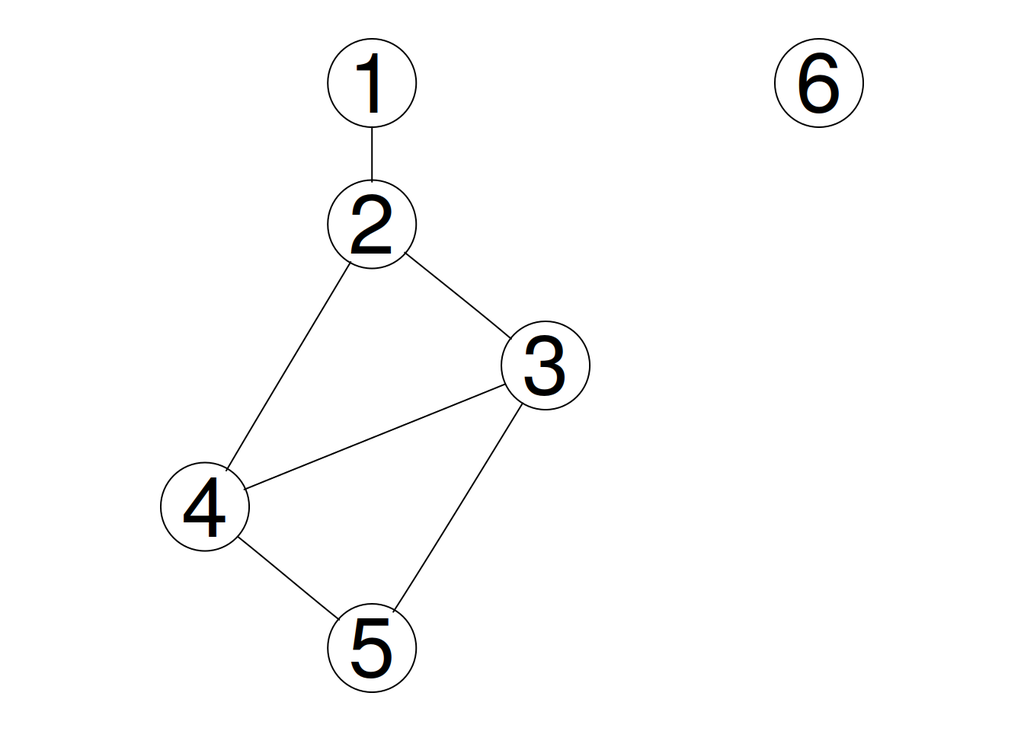

```r
suppressMessages(library("gRbase"))
suppressMessages(library("graph"))
suppressMessages(library("RBGL"))
suppressMessages(library("Rgraphviz"))

g3 <- ug(~ 1:2 + 2:3:4 + 3:5 + 4:5 + 6)
plot(g3)
```

En el caso anterior la dimension $X_6$ es aislada, lo que induce que esta dimension sea `independiente estocasticamente` de las restantes bajo $p(\cdot)$.

## 2.2 Propiedad de Markov

La nocion de **simetria estocastica** entre las $J$ dimensiones de $X$ a traves de $\mathbb{P}(\cdot)$ (o $p(\cdot)$) se **especifica** o se **extrae** del **grafo de dependencia asociado.**

En particular, si $\mathcal{G}=(V,E)$ es el **grafo de dependencia** asociado con $p(\cdot)$, y existen subconjuntos
$$A\subset V,\\
B\subset V,$$

separados por otro subconjunto
$$S\subset V,$$
entonces, $X_A$ y $X_B$ seran condicionalmente independientes dado $X_S$, i.e.
$$(X_A \mathrel{\text{$\perp\mkern-10mu\perp$}}X_B) \ | \ X_S.$$

De acuerdo a lo anterior, la probabilidad $p(x_A,x_B,x_S)$ cumplira con la **factorizacion**,
$$p(x_A,x_B,x_S)=\phi_{A,S}(x_A,x_S)\phi_{B,S}(x_B,x_S).$$

### 2.2.1 Ejemplo

Retomando el ejemplo anterior con `g3`, podemos ver que
$$p(x)=p(x_1,x_2,x_3,x_4,x_5,x_6)=\left\{\phi_{1,2}(x_1,x_2)\right\} \times \left\{\phi_{2,3,4}(x_2,x_3,x_4)\phi_{3,5}(x_3,x_5)\phi_{4,5}(x_4,x_5)\right\}\times\left\{\phi_{6}(x_6)\right\},$$
por lo que integrando $X_3$ y $X_6$ tenemos que
$$(X_{1} \mathrel{\text{$\perp\mkern-10mu\perp$}}X_{4,5}) \ | \ X_{2},$$
con
$$X_{4,5}=(X_{4},X_{5}).$$

Este resultado es extraido de `g3`, de la siguiente forma:

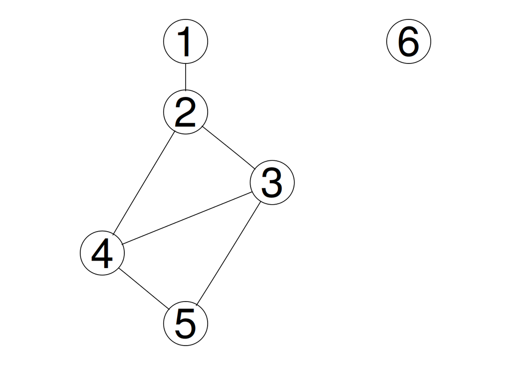

```r
plot(g3)
```

```r
separates(c("4","5"), "1", "2", g3)
```

```
## [1] TRUE
```

# 3 Tablas de contingencia

Para un conjunto de datos de $J$ `variables/dimensiones`, donde cada dimension contiene $K_j$ categorias, $\mathcal{X}_j=\{1,\ldots,K_j\}$, la `tabla de contingencia` $J$-dimensional se define como el arreglo $J$-dimensional
$$T_J=\left(n_{e(1),\ldots,e(J)}\right),$$
donde
$$e(j)\in \mathcal{X}_j,$$
para $j=1,\ldots,J$.

Es decir, cada dimension $j$ del arreglo contiene $K_j$ entradas.

Si la tabla de contingencia de calcula a partir de $n$ datos, se cumple que
$$n=\sum_{\{e(1),\ldots,e(J)\}}n_{e(1),\ldots,e(J)},$$
donde
$$n_{e(1),\ldots,e(J)} = \#\{x_i:x_{i1}=e(1),\ldots,x_{iJ}=e(J)\},$$
donde $x_i$s corresponden a los vectores $J$-dimensionlaes que componen los $n$ datos, con
$$x_i=(x_{i1},\ldots,x_{iJ}).$$

> Los datos tipicamente estan reportados como un `data.frame` donde cada `renglon` corresponde al vector $x_j$ y las columnas corresponden a las $J$ `variables/dimensiones` (en `R` reportadas como `as.factor`).

## 3.1 Ejemplo

Consideremos los datos ilustrativos de 409 lagartos en las que se miden:

- Especie, $S$ o $X_1$
- Diametro, $D$ o $X_2$
- Alto, $H$ o $X_3$.

```r
suppressMessages(library("gRbase"))
data(lizardRAW, package="gRbase")
data <- lizardRAW
colnames(data) <- c("X2","X3","X1")
data <- data[,c("X1","X2","X3")]
head(data)
```

```
##      X1  X2     X3
## 1  dist  >4  >4.75
## 2  dist  >4  >4.75
## 3 anoli <=4 <=4.75
## 4 anoli  >4 <=4.75
## 5  dist  >4 <=4.75
## 6 anoli <=4 <=4.75
```

```r
dim(data)
```

```
## [1] 409   3
```

```r
is.factor(data$X1)
```

```
## [1] TRUE
```

Los `factores` para $X_1,X_2,X_3$ son:

```r
unique(data$X1)
```

```
## [1] dist  anoli
## Levels: anoli dist
```

- $\mathcal{X_2}=\{1,2\}$, donde
  $$\begin{cases}
  x_2=1,& \text{diam <= 4}\\
  x_2=2,& \text{diam > 4}\\
  \end{cases}$$

```r
unique(data$X2)
```

```
## [1] >4  <=4
## Levels: <=4 >4
```

- $\mathcal{X_3}$ donde
  $$\begin{cases}
  x_3=1,& \text{height <= 4.75}\\
  x_3=2,& \text{height > 4.75}\\
  \end{cases}$$

```r
unique(data$X3)
```

```
## [1] >4.75  <=4.75
## Levels: <=4.75 >4.75
```

La `tabla de contingencia` (en este caso, el `arreglo de tres dimensiones`) es:

```r
data.tc <- table(data)
data.tc
```

```
## , , X3 = <=4.75
##
##        X2
## X1      <=4 >4
##   anoli  86 35
##   dist   73 70
##
## , , X3 = >4.75
##
##        X2
## X1      <=4 >4
##   anoli  32 11
##   dist   61 41
```

```r
sum(data.tc)
```

```
## [1] 409
```

## 3.2 Proposito

El estudio de `tablas de contingencia` tiene en la estadistica dos propositos fundamentales:

1. Estudiar las `interacciones` o `comovimientos` o `dependencia` entre las $X_j$s (en todos sus categorias).
2. Anticipar futuros valores de $n_{e(1),\ldots,e(J)}$ para cada `celda` en la `tabla de contingencia`, con base en observaciones previas.

### 3.2.1 Notacion

En el ejemplo previo, consideramos:

- Denotaremos el conjunto de `vertices` como
  $$V=\{1,2,3\},$$
  correspondientes a las tres `dimnesiones/variables`
  $$\{X_1,X_2,X_3\}.$$
- El `vector aleatorio discreto`, $X_i$, es denotado por
  $$X_i=(X_{i,v}:v\in V),$$
  para $i=1,\ldots,n=409$.
- La `configuracion` de $X_i$, que se refiere a las categorias especificas de la observacion $i$, se denota como
  $$x_{i}=(x_{i,v}:v\in V),$$
  donde cada
  $$x_j=e(j)\in \mathcal{X}_j,$$
  para $j=1,\ldots,J=3$.
- Los `conteos` son las entradas de la `tabla de contingencia`, y corresponden a los casos
  $$n_{e(1),e(2),e(3)}=\#\{x_{i,v}:x_{i,1}=e(1),x_{i,2}=e(2),x_{i,3}=e(3)\}.$$
- La `probabilidad` de que una observacion $X_v$ sea igual a $e(v)=(e(1),\ldots,e(J))$ es denotada por
  $$\theta_v=p(x_{v})=\mathbb{P}(X_{v}=x_v)=\mathbb{P}(X_1=e(1),\ldots,X_J=e(J)).$$

### 3.2.2 Tablas marginales

Para una `tabla de contingencia reducida` o `subtabla` correspondiente a un subconjunto `A\subset V`, tenemos los siguiente:

- $X_A=\left(X_v:v\in A\right)$.
- La configuracion correspondiente a $A$ sera denotada por $x_A$.
- La `tabla marginal` (o `subtabla de contingencia`) para $A$ esta definida por los conteos
  $$n_{x_A}=\#\{x_{i,v}:v\in A, x_{i,A}=e(A)\}.$$
- La `probabilidad marginal` de una observacion en la `tabla marginal`, $X_A$, se define como,
  $$\theta_A=p(x_{A})=\sum_{x':x'_A=x_A} \mathbb{P}(X_{v}=x'_v)=\sum_{x':x'_A=x_A} p(x'_v).$$

Es decir, calculamos las probabilidades marginales para las `dimensiones` o `variables` en $A$.

### 3.2.3 Ejemplo

En el caso del ejemplo previo, consideramos `marginalizar` respecto a `X_3`, i.e.
$$A=\{1,2\},$$
por lo que estaremos interesados en calcular la tabla de contingencias para
$$(X_1,X_2)$$
.

Esto lo podemos calcular de dos formas:

1. Marginalizacion de la `tabla original`, i.e.

```r
tableMargin(data.tc, c("X1","X2"))
```

```
##        X2
## X1      <=4  >4
##   anoli 118  46
##   dist  134 111
```

```r
sum(tableMargin(data.tc, c("X1","X2")))
```

```
## [1] 409
```

2. Como la tabla de contingencia de la `tabla reducida` respecto a $A$, i.e.

```r
table(data[,c("X1","X2")])
```

```
##        X2
## X1      <=4  >4
##   anoli 118  46
##   dist  134 111
```

```r
sum(table(data[,c("X1","X2")]))
```

```
## [1] 409
```

## 3.3 Representaciones

Una `tabla de contingencia` puede representarse de dos formas complementarias:

1. En terminos de sus `configuraciones`,
   $$T_V=(n_v)_{v\in V},$$
   sujeto a
   $$n_v \geq 0,$$
   para todo $v \in V$, y
   $$\sum_{v} n_v = n.$$

Por ejemplo:

```r
data.tc <- table(data)
data.tc
```

```
## , , X3 = <=4.75
##
##        X2
## X1      <=4 >4
##   anoli  86 35
##   dist   73 70
##
## , , X3 = >4.75
##
##        X2
## X1      <=4 >4
##   anoli  32 11
##   dist   61 41
```

2. En terminos de sus `probabilidades`,
   $$T_V=(\theta_v)_{v\in V},$$
   sujeto a
   $$\theta_v \geq 0,$$
   para todo $v \in V$, y
   $$\sum_{v} \theta_v = 1.$$

Por ejemplo:

```r
data.prob <- table(data)/sum(table(data))
data.prob
```

```
## , , X3 = <=4.75
##
##        X2
## X1             <=4         >4
##   anoli 0.21026895 0.08557457
##   dist  0.17848411 0.17114914
##
## , , X3 = >4.75
##
##        X2
## X1             <=4         >4
##   anoli 0.07823961 0.02689487
##   dist  0.14914425 0.10024450
```

> En los siguientes modelos, estudiaremos `diferentes representaciones` de las probabilidades $\theta_v$ asociadas con una `tabla de contingencia` $T_v$.

# 4 Modelos loglineales

> Nota:- Las siguientes definiciones hacen referencia al `ejemplo previo`.

Los `modelos loglineales`, representan las probabilidades $\theta_v$ de una tabla de contingencia $T_v$ de manera `logaditiva`, como
$$\log \theta_v = \alpha^0,$$
donde $\alpha^0$ es un factor unico comun para todas las `dimensiones` en $v$ y todas sus `categorias`.

Otra alternativa, corresponderia a especificar,
$$\log \theta_v = \alpha^{1}_{e(1)} + \alpha^{2}_{e(2)} + \alpha^3_{e(3)},$$
donde $\alpha^j_{e(j)}$ corresponde a un factor particular para la `dimension` $j$ en la `categoria $e(j)$`, con $j=1,\ldots,J=3$.

De manera complementaria, podriamos especificar las `probabilidades` de la siguiente forma:
$$\log \theta_v = \alpha^0 + \alpha^{12}_{e(1,2)} + \alpha^{23}_{e(2,3)} + \alpha^{13}_{e(1,3)},$$
donde $\alpha^{jk}_{e(j,k)}$ corresponde a un factor particular para las `dimensiones` $\{jk\}$, con $j,k=1,\ldots,J=3$, y sus correspondientes `categorias` $\{e(j),e(k)\}$.

> Asi, podemos tener `multiples representaciones` para $\log \theta_{v}$ asociadas con una misma tabla de contingencia $T_v$.

## 4.1 Estructura

> La estructura en el `modelo loglineal` se obtiene estableciendo los terminos de interaccion en $0$ siguiendo el principio de que si un termino de interaccion se establece en $0$, todos los terminos de orden superior que contienen esos terminos de interaccion tambien deben establecerse en $0$.

### 4.1.1 Ejemplo

En el caso del `ejemplo previo`, consideremos que $\alpha^{2,3}_{e(2,3)}=0$, entonces todos los factores que contengan $\{e(1),e(2)\}$ deben ser iguales a $0$, i.e.
$$\alpha^{1,2,3}_{e(1,2,3)}=0,$$
para
$$e(1,2,3)=\left(e(1),e(2),e(3)\right).$$

## 4.2 Generadores

Los `modelos loglineales` pueden especificarse en terminos de sus `generadores` (`factores individuales` y `factores de interaccion` distintos de $0$).

Por ejemplo, respecto al `ejemplo previo`, si:

- definimos $\alpha^{2,3}_{e(2,3)}=0$ y
- definimos $\alpha^{1,2,3}_{e(1,2,3)}=0$,

tenemos que los `generadores` pueden listarse como
$$\{ \{1\}, \{2\}, \{3\}, \{(1,2)\}, \{(1,3)\} \}=\{X_1,X_2,X_3,X_{1,2},X_{1,3}\}.$$

### 4.2.1 Modelo saturado

El `modelo saturado` se define como la representacion de $\log \theta_v$ correspondiente a no tener factores $a$s iguales a cero, i.e. en el `ejemplo previo`,
$$\log \theta_v = \alpha^0 + \sum_{j}\alpha^j_{e(j)} + \sum_{jk} \alpha^{j,k}_{e(j,k)} + \alpha^{1,2,3}_{e(1,2,3)}.$$

Los `generadores del modelo saturado`, por definicion, son
$$\{ \{1\}, \{2\}, \{3\}, \{(1,2)\}, \{(2,3)\}, \{(1,3)\}, \{(1,2,3)\}\}.$$

> Nota:- El `modelo saturado` es, por construccion, no identificable estructuralmente hablando.

### 4.2.2 Modelo independiente

El `modelo independiente` se define como el `modelo loglineal` para el cual todos los factores de interaccion entre `dimensiones/variables` son iguales a cero, i.e. en el `ejemplo previo`
$$\log \theta_v = \alpha^0 + \sum_{j} \alpha^j_{e(j)}.$$

En este caso, los generadores corresponden a las `dimensiones/variables` marginales
$$\{1,2,3\}.$$

> Nota:- El `modelo independiente` considera solamente las `contribuciones marginales` de cada `dimension`.

## 4.3 Grafo probablistico

La `tabla de contingencia`, $T_v$, vista como un `grafo de probabilidad`, representara las `proabilidades` $\theta_v$ de acuerdo al `grafo inducido`
$$\mathcal{G}(V,E),$$
donde

- El conjunto $V$ corresponde a los `vertices/dimensiones` y
- El conjunto $E$ corresponde a los `bordes` inducidos por los `generadores` del `modelo loglineal correspondiente`.

De esta manrea buscaremos representar las `probabilidades` de la siguiente forma
$$\theta_{v}=\prod_{G\in \mathcal{C}_G}\phi_{A},$$
donde
$$\mathcal{C}_G=\{G_1,\ldots,G_Q\},$$
es la `clase generadora` del `modelo loglineal` correspondiente, siendo $Q$ el numero de elementos en $\mathcal{C}_G$.

### 4.3.1 Modelo independiente

Por ejemplo, retomando el `ejemplo previo`, y considerando el `modelo independiente` tenemos que la `clase generadora` corresponde a
$$\mathcal{C}_G=\left\{ \{1\}, \{2\}, \{3\} \right\},$$
i.e. $Q=3$, con $G_1=\{1\}$, $G_2=\{2\}$ y $G_3=\{3\}$.

## 4.4 Factorizacion

A partir de la descompocion de $\theta_v$, podremos contrastar o aplicar el `teorema de factorizacion` de grafos:

> Consideremos que $\mathcal{G}(V,E)$ define un `grafo de probabilidades` $\left(\theta_v\right)_{v\in V}$ con $\theta_v=\prod_{G\in \mathcal{G}_G}\phi_G$, con $\mathcal{G}_C$ inducida por $E$. Si existen subconjuntos $A$, $B$ y $S$ de $V$ tales que
> $$\theta_v = \phi_{A,S} \times \phi_{B,S},$$
> diremos que
> $$A\mathrel{\text{$\perp\mkern-10mu\perp$}}B|S.$$

Es decir, las `variables/dimensiones` en $A$ y en $B$ seran condicionalmente indeppendientes dado $S$.

# 5 Inferencia

Hasta el momento, hemos revisado:

- Teoria relevante de `grafos matematicos`
- Especificaciones de `grafos probabilisticos`
- Conexion con `modelos loglineales`.

Todo esto para encontrar `especificaciones` de las probabilidades $\theta_v$s de una tabla de contingencia $T_v$.

Recordemos que las `probabilidades` estan referidas a cada una de las observaciones, i.e. la tabla de contingencia $T_v$ del `ejemplo previo` se calcula como:

```r
data.prob
```

```
## , , X3 = <=4.75
##
##        X2
## X1             <=4         >4
##   anoli 0.21026895 0.08557457
##   dist  0.17848411 0.17114914
##
## , , X3 = >4.75
##
##        X2
## X1             <=4         >4
##   anoli 0.07823961 0.02689487
##   dist  0.14914425 0.10024450
```

> Esto, considerando que las $\theta_v$s con `probabilidades no muestrales`.

## 5.1 Parametrizacion

Asi, el `grafo probabilistico` asociado con el `grafo` $\mathcal{G}(V,E)$ es parametrizado por
$$\{\theta_{v}:v\in V\},$$
con
$$\theta_{v} \geq 0,$$
y
$$\sum_{v}\theta_v = 1.$$

Es decir, el `espacio parametral` del `grafo probabilistico` es el simplejo de dimension $\left(\prod_{j} K_j -1\right)$.

## 5.2 Verosimilitud

Asi, la evidencia provista por un conjunto de `datos/configuraciones` de `n` objetos es representada por
$$lik\left(\theta_v|x_1,\ldots,x_n\right)=\prod_{i=1}^{n}\theta_{e(i)},$$
con
$$e(i)=\left(e(1),\ldots,e(J)\right),$$
la configuracion correspondiente a la observacion $i$.

## 5.3 Siguiente sesion

- En la siguiente sesion estudiaremos el aspecto inferencial (`frecuentista` y `bayesiano`) asociado con los modelos de `grafos probabilisticos` para tablas de contingencia $T_v$.

# 6 Lecturas complementarias

- Nota personal sobre tablas de contingencia $2\times 2$. `est46114_s19_suplemento1.pdf`
- Coppi, *An Introduction to Multi-Way Data and Their Analysis.* `est46114_s19_suplemento2.pdf`